# Week 6 - Production & Scaling

Deploying AI Agents at Scale

**Key Quote:**

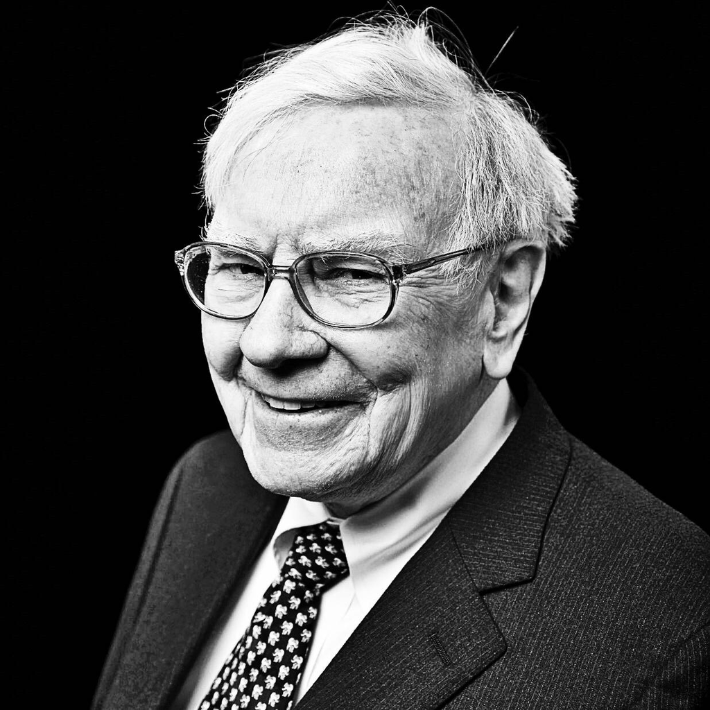

Warren Buffett

> *“When the tide goes out, the truth appears.”*  
> — Warren Buffett

# Lesson Overview

| Segment | Duration |
| --- | --- |
| Lecture: What Changes When You Go to ProductionKK? | 10 minutes |
| Live Demo: Context Cost Simulation | 10 minutes |
| Activity: Production Hardening Exercise | 30 minutes |
| Wrap-up: Principles & Ethics | 10 minutes |

**Learning Objectives:** By the end of this lesson, students will be able to:

- Understand cost dynamics at scale (token economics)
- Design context management strategies for production
- Build a stateful multi-user interface
- Prevent runaway token growth
- Think in terms of reliability, concurrency, and infrastructure
- Identify scaling failure modes before they happen

**Colab Notebook for Today:**

> [Wellness Agent - BROKEN (Activity Notebook)](https://colab.research.google.com/github/WilJones-Red/Agentic_Bootcamp/blob/main/Projects/Wellness_Agent_BROKEN.ipynb)  
> *(It is recommended to download a copy of the notebook to your own google colab)*

**Reference Video/Material:**

> [Advanced LangChain Memory](https://docs.langchain.com/oss/python/langchain/short-term-memory) This lesson introduces various basic memory management strategies. This resource will provide a deeper dive into memory types and how to implement them into your agents via LangChain.

> [Business Mindset on Scaling](https://www.youtube.com/watch?v=DNF87O_kF-k) This video connects a proper mindset on scalable businesses to our discussion on production-ready agents. You will see how resilience, discipline, and strong fundamentals apply not just to companies, but to AI systems built to last.

> [LangSmith Deployment - Reference Docs](https://docs.langchain.com/langsmith/deployments) This documentation provides an overview of deploying LangSmith in production environments, which is relevant for understanding how to make production-ready agents like the Wellness Agent - for our purposes it is still in a non-production state.

> [LangSmith 101 for AI Observability - James Briggs](https://www.youtube.com/watch?v=Iyc80hY2yYk)  
> This lesson applies LangSmith observability concepts specifically to the production-ready Wellness Agent. You will remember this video as it was referenced previously in the diagnostics lesson.

# Lecture (10 Minutes)

## What Changes When You Go to Production?

### The Key Shift

Building an agent in a notebook is **fundamentally different** from running it in production. Here’s the reality check:

| In a Notebook | In Production |
| --- | --- |
| One user (you) | 50–10,000 users |
| Small context (few messages) | Persistent conversations (hundreds of messages) |
| No cost pressure | Real money per token |
| No concurrency | Infrastructure bottlenecks |
| No legal constraints | Privacy, compliance, liability |

**The Wellness Agent notebook you’ve been working with is a prototype. This lesson is about making it production-ready.**

## Core Scaling Problems in Agentic AI

### Problem 1: Token Explosion

**Context grows linearly. Cost grows super-linearly.**

Let’s do the math:

```
Without context cap:
- Message 1: Context = 1 message → Cost = 1x
- Message 2: Context = 2 messages → Cost = 2x
- Message 3: Context = 3 messages → Cost = 3x
- ...
- Message 100: Context = 100 messages → Cost = 100x

Cost per prompt = p × base_cost_factor
Cumulative cost after p prompts = p(p+1)/2 × base_cost_factor
```

**Context cap is not optional—it’s financial survival.**

### Problem 2: Multi-User State

**One notebook session ≠ 100 concurrent users.**

When you scale to multiple users, you must handle:

1. **User sessions** - Each user needs their own conversation history
2. **Conversation storage** - Where does the data live? Memory? Database?
3. **Session expiration** - Do conversations last forever? 1 day? 30 days?
4. **Isolation between users** - User A cannot see User B’s data

**In production:** You need persistent storage (SQLite/PostgreSQL), session isolation, and cleanup policies.

### Problem 3: Latency & UX

**Users expect < 2–3 second response times.** Factors: LLM speed, tool execution, context size. Use streaming responses in production.

### Problem 4: Reliability

**Agents can:** - **Loop** - Call the same tool 50 times in a row - **Retry infinitely** - Never give up on a failing API call - **Hallucinate tool calls** - Invent tools that don’t exist - **Over-call APIs** - Hit rate limits on external services - **Chain tools inefficiently** - Use 5 tools when 1 would suffice

**In production: You must constrain behavior.**

```python
# Production safety controls
MAX_TOOL_CALLS_PER_TURN = 5
MAX_RETRIES = 3
TIMEOUT_SECONDS = 30
MAX_RESPONSE_LENGTH = 2500

# LangGraph recursion limit
agent = create_react_agent(
    llm,
    tools,
    state_modifier="system message here",
    max_iterations=MAX_TOOL_CALLS_PER_TURN  # Prevents infinite loops
)
```

**Without these limits, a single misbehaving agent can:** - Drain your API budget - DOS your database - Block other users from getting responses

## Context as a Budget

**Production rule: Never let context grow unbounded.**

Think of context as a **limited resource** like memory or disk space. You have three strategies:

**Three strategies:**

1. **Sliding Window** - Keep last N messages (simple, predictable)
2. **Summary Memory** - Compress old messages into summary (retains info, adds LLM cost)
3. **Retrieval-Based** - Vector DB fetch relevant history (scales best, needs infrastructure)

### The Wellness Agent Approach

The production Wellness Agent uses **Sliding Window + Summary**:

```python
class AgentConfig(BaseModel):
    max_messages_per_user: int = 30               # hard cap
    summarize_after_messages: int = 18            # create summary at this point
    max_summary_chars: int = 1200                # keep summaries small
```

**Why this works for wellness tracking:** - Recent meals/workouts are most important → sliding window - Long-term goals/preferences go in summary → summary memory - Most users don’t need more than 30-message history

**The `context_growth_cap = 50` in your simulation is not optional in production. It’s survival.**

# Live Demo (10 Minutes)

## Context Cost Simulation

Let’s see the cost explosion in action. Run this simulation in a new Python cell:

```python
import numpy as np
import matplotlib.pyplot as plt

# Simulation parameters
num_users = 50
days = 30
prompts_per_day_per_user = 10
base_cost_per_1k_tokens = 0.002  # $0.002 per 1k tokens (example rate)
avg_tokens_per_message = 500

# Scenario 1: No context cap (context grows forever)
def simulate_no_cap(num_users, days, prompts_per_day):
    daily_costs = []
    cumulative_cost = 0

    for day in range(days):
        day_cost = 0
        for user in range(num_users):
            # Each user has sent (day * prompts_per_day) messages so far
            context_size = day * prompts_per_day + prompts_per_day

            # Cost for this day's prompts (context grows with each prompt)
            for prompt_num in range(1, prompts_per_day + 1):
                current_context = context_size + prompt_num
                tokens = current_context * avg_tokens_per_message
                cost = (tokens / 1000) * base_cost_per_1k_tokens
                day_cost += cost

        cumulative_cost += day_cost
        daily_costs.append(cumulative_cost)

    return daily_costs

# Scenario 2: Context cap at 50 messages
def simulate_with_cap(num_users, days, prompts_per_day, cap=50):
    daily_costs = []
    cumulative_cost = 0

    for day in range(days):
        day_cost = 0
        for user in range(num_users):
            # Context is capped at 50 messages
            context_size = min(cap, day * prompts_per_day + prompts_per_day)

            # Cost is constant after hitting the cap
            for prompt_num in range(prompts_per_day):
                tokens = context_size * avg_tokens_per_message
                cost = (tokens / 1000) * base_cost_per_1k_tokens
                day_cost += cost

        cumulative_cost += day_cost
        daily_costs.append(cumulative_cost)

    return daily_costs

# Run simulations
no_cap_costs = simulate_no_cap(num_users, days, prompts_per_day_per_user)
capped_costs = simulate_with_cap(num_users, days, prompts_per_day_per_user, cap=50)

# Plot results
plt.figure(figsize=(12, 6))
plt.plot(range(1, days + 1), no_cap_costs, label='No Context Cap', linewidth=2, color='red')
plt.plot(range(1, days + 1), capped_costs, label='Context Cap = 50 messages', linewidth=2, color='green')
plt.xlabel('Days', fontsize=12)
plt.ylabel('Cumulative Cost ($)', fontsize=12)
plt.title(f'Cumulative LLM Cost Over {days} Days ({num_users} users, {prompts_per_day_per_user} prompts/day)', fontsize=14)
plt.legend(fontsize=11)
plt.grid(True, alpha=0.3)
plt.tight_layout()
plt.show()

# Print final costs
print(f"\n{'='*60}")
print(f"Final Cost Comparison (after {days} days):")
print(f"{'='*60}")
print(f"No Context Cap:        ${no_cap_costs[-1]:.2f}")
print(f"With Cap (50 msg):     ${capped_costs[-1]:.2f}")
print(f"Savings:               ${no_cap_costs[-1] - capped_costs[-1]:.2f} ({((no_cap_costs[-1] - capped_costs[-1]) / no_cap_costs[-1] * 100):.1f}%)")
print(f"{'='*60}\n")
```

[output not shown]

## Key Observations

**Quick exercise:** Try `num_users = 500`. What happens to the gap?

# Activity (30 Minutes)

## Production Hardening Exercise

**Objective:** You will analyze a production agent implementation that contains critical scaling vulnerabilities. Your task is to systematically identify these vulnerabilities, understand their impact on production systems, and implement robust fixes that ensure reliability and cost-effectiveness at scale.

### The Broken Agent

Here’s the starting code students receive:

```python
# BROKEN PRODUCTION AGENT - DO NOT USE IN REAL PRODUCTION
import os
from langchain_google_genai import ChatGoogleGenerativeAI
from langchain_core.messages import HumanMessage, AIMessage
from langchain.tools import tool

# LLM setup
llm = ChatGoogleGenerativeAI(model="gemini-2.5-flash", temperature=0.4)

# Tools
@tool
def log_food(name: str, calories: float) -> str:
    """Log a food item."""
    return f"Logged {name}: {calories} cal"

@tool
def log_workout(name: str, minutes: float) -> str:
    """Log a workout."""
    return f"Logged {name}: {minutes} min"

tools = [log_food, log_workout]

# PROBLEM: Global conversation store (no user isolation)
conversation_history = []

# PROBLEM: No context cap
def chat(user_message: str):
    conversation_history.append(HumanMessage(content=user_message))

    # PROBLEM: Sends entire conversation history every time
    response = llm.invoke(conversation_history)
    conversation_history.append(response)

    # PROBLEM: No token counting
    # PROBLEM: No rate limiting
    # PROBLEM: No logging
    # PROBLEM: No error handling

    return response.content

# Usage (pretend this is multiple users)
print(chat("I ate a salad"))
print(chat("I went for a run"))
```

## Task 1 – Identify Scaling Risks (8 min)

Students must list:

1. **Where money is wasted**
   - Hint: Look at what gets sent to the LLM on each call
2. **Where memory grows**
   - Hint: What happens to `conversation_history` over time?
3. **Where failure could occur**
   - Hint: What if the LLM call times out? What if it returns an error?
4. **Where multiple users would collide**
   - Hint: What if two users call `chat()` at the same time?

**Deliverable:** List of 4-6 specific vulnerabilities in the code.